# **Appendix** Computation of Large Spatial Datasets with the M function

Eric Marcon

Florence Puech

2026 October 16

The code used in the article “Computation of Large Spatial Datasets with the *M* function” is detailed here.

# 1 The M function

## 1.1 Data simulation

### 1.1.1 Drawing the points

A set of points is drawn at random with the following parameters:

- the number of points,
- the proportion of controls,
- the shape and scale of the gamma distribution.

In this appendix, the number of points of the examples is reduced to 5000 to limit computing overhead. The parameter `par_points_nb` can be set to 100,000 to reproduce the exact figures of the article.

```r
library("tidyverse")
library("spatstat")
library("dbmss")

par_points_nb <- 5000 # 1E5 in the article
par_case_ratio <- 1/20
par_size_gamma_shape <- 0.95
par_size_gamma_scale  <- 10
```

The `X_csr()` function is used to draw a series of points according to certain parameters. The `points_nb` argument, which sets the number of points, can be modified; the other parameters have their values set above.

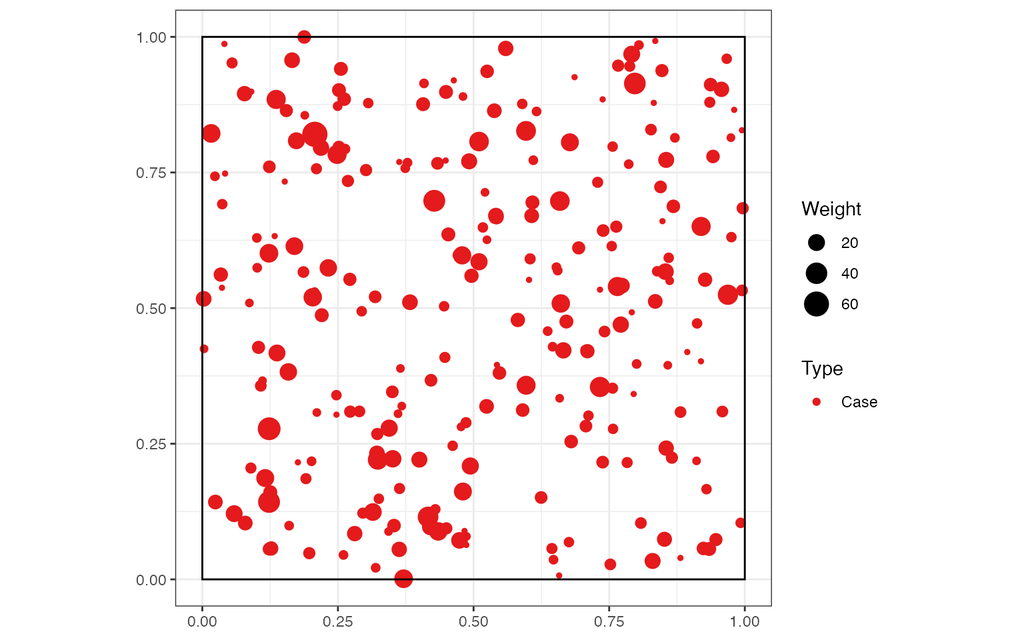

```r
X_csr <- function(
    points_nb,
    case_ratio = par_case_ratio,
    size_gamma_shape = par_size_gamma_shape,
    size_gamma_scale = par_size_gamma_scale) {
  points_nb %>%
    runifpoint() %>%
    as.wmppp() ->
    X
  cases_nb <- round(points_nb *  case_ratio)
  controls_nb <- points_nb - cases_nb
  c(rep("Control", controls_nb), rep("Case", cases_nb)) %>%
    as.factor() ->
    X$marks$PointType
  rgamma(
    X$n,
    shape = size_gamma_shape,
    scale = size_gamma_scale
  ) %>%
    ceiling() ->
    X$marks$PointWeight
  X
}

# Example
X <- X_csr(par_points_nb)
# Map the cases
autoplot(X[X$marks$PointType == "Case"])
```

The size distribution is shown in the histogram below:

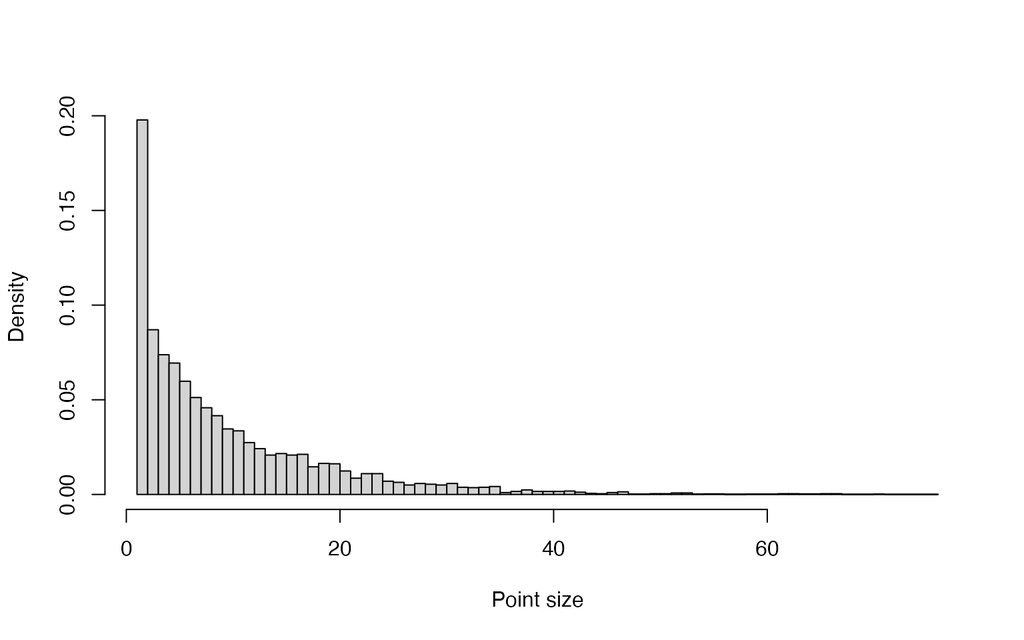

```r
# Point size distribution
hist(
  X$marks$PointWeight,
  breaks = unique(X$marks$PointWeight),
  main = "",
  xlab = "Point size"
)
```

The `X_matern()` function is used to draw a semiset of points whose Cases are concentrated by a Matérn (1960) process. The parameters are

- $\kappa$: the expected number of clusters,
- `scale`: their radius.

```r
# Expected number of clusters
par_kappa <- 20
# Cluster radius
par_scale <-  0.1
```

The function code is as follows:

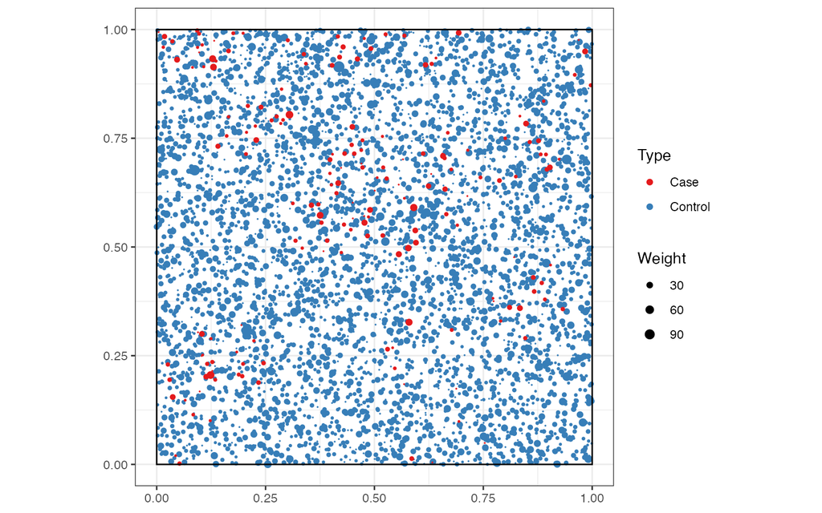

```r
X_matern <- function(
    points_nb,
    case_ratio = par_case_ratio,
    kappa = par_kappa,
    scale = par_scale,
    size_gamma_shape = par_size_gamma_shape,
    size_gamma_scale = par_size_gamma_scale) {
  cases_nb <- round(points_nb *  case_ratio)
  controls_nb <- points_nb - cases_nb
  # CSR controls
  controls_nb %>%
    runifpoint() %>%
    superimpose(
      # Matern cases
      rMatClust(
        kappa = kappa,
        scale = scale,
        mu = cases_nb / kappa
      )
    ) %>%
    as.wmppp() ->
    X
  # Update the number of cases
  cases_nb <- X$n - controls_nb
  c(rep("Control", controls_nb), rep("Case", cases_nb)) %>%
    as.factor() ->
    X$marks$PointType
  rgamma(
    X$n,
    shape = size_gamma_shape,
    scale = size_gamma_scale
  ) %>%
    ceiling() ->
    X$marks$PointWeight
  X
}

# Example
X <- X_matern(par_points_nb)
# Map the cases
autoplot(X) +
  scale_size(range = c(0, 3))
```

### 1.1.2 Gridding the space

The number of rows and columns is set:

```r
# Number of rows and columns
par_partitions <- 20
```

The `group_points()` function gathers all the points it contains at the centre of each grid cell. This simulates the usual approximation of the position of the points in an administrative unit to the position of its centre. The position of the points is slightly noisy to enable *M* to be calculated. The `group_points_to_plot()` function merges the points to produce a map.

```r
# Group points into cells
group_points <- function(X, partitions = par_partitions) {
  X %>%
    with(tibble(
      x,
      y,
      PointType = marks$PointType,
      PointWeight = marks$PointWeight)
    ) %>%
    mutate(
      x_cell = ceiling(x * partitions) / partitions - 1 / 2 / partitions,
      y_cell = ceiling(y * partitions) / partitions - 1 / 2 / partitions,
      .keep = "unused"
    ) %>%
    rename(x = x_cell, y = y_cell) %>%
    as.wmppp(window = X$window, unitname = X$window$units) %>%
    rjitter()
}
# Group points and merge them
group_points_to_plot <- function(X, partitions = par_partitions) {
  X %>%
    with(tibble(
      x,
      y,
      PointType = marks$PointType,
      PointWeight = marks$PointWeight)
    ) %>%
    mutate(
      x_cell = ceiling(x * partitions) / partitions - 1 / 2 / partitions,
      y_cell = ceiling(y * partitions) / partitions - 1 / 2 / partitions
    ) %>%
    group_by(PointType, x_cell, y_cell) %>%
    summarise(n = n(), PointWeight = sum(PointWeight)) %>%
    rename(x = x_cell, y = y_cell) %>%
    as.wmppp(window = X$window, unitname = X$window$units)
}
```

The figure is obtained using the following code:

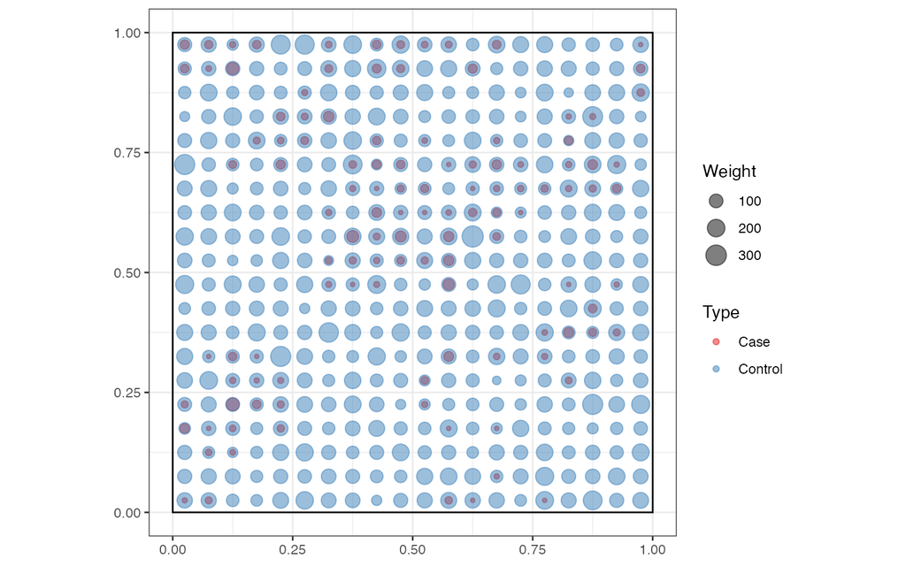

```r
X %>% group_points_to_plot() %>% autoplot(alpha = 0.5)
```

## 1.2 Computing *M* with the *dbmss* package

The distances at which the *M* function is calculated are chosen from `r`.

```r
r <- c((0:9) / 100, (2:10) / 20)
```

In the *dbmss* package (Marcon et al., 2015), the function applies to a set of points, object of class `wmppp`, or to a matrix of distances, object of class `Dtable`.

We start with an array (data.frame) containing the columns `x`, `y`, `PointType` and `PointWeight`.

The spatial co-ordinates of the points are given by the `x` and `y` columns.

```r
# Extract a dataframe from the point set
points_df <- with(X, data.frame(x, y, marks))
head(points_df)
```

```
##           x          y PointWeight PointType
## 1 0.4550716 0.31775637           4   Control
## 2 0.6463730 0.04396279           2   Control
## 3 0.9156488 0.23361975           2   Control
## 4 0.9724551 0.87464816           1   Control
## 5 0.8907927 0.26205266           4   Control
## 6 0.9561687 0.96813173           7   Control
```

### 1.2.1 Point pattern

The `Mhat()` function is used to estimate the value of the *M* function.

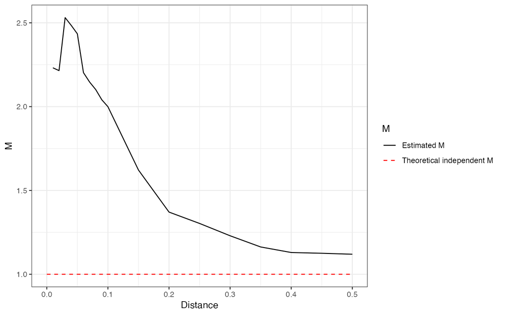

```r
X %>%
  Mhat(r = r, ReferenceType = "Case") %>%
  autoplot()
```

The `Menvelope()` function is used to calculate the confidence interval of the function value under the null hypothesis of random location of the points. The global confidence interval (Duranton & Overman, 2005) is calculated by specifying the argument `Global = TRUE`.

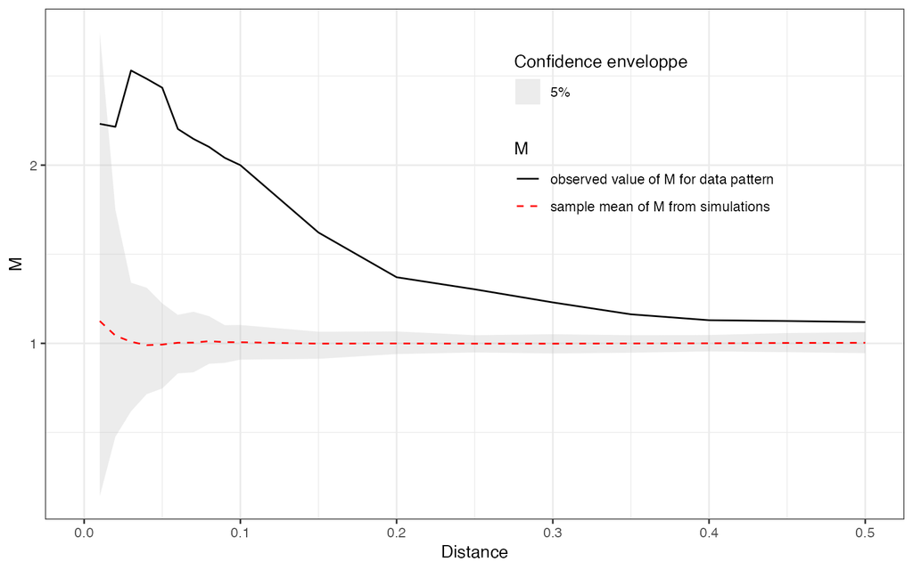

```r
X %>%
  MEnvelope(r = r, ReferenceType = "Case", Global = TRUE) %>%
  autoplot() +
  theme(
    legend.position = c(0.7, 0.75),
    legend.background = element_blank()
  )
```

The confidence envelope contains 95% of the simulated values of the M function under the null hypothesis of independence between points. It is much smaller in the article because it decreases with the number of points.

### 1.2.2 Distance matrix

The `as.Dtable()` function is used to create a `Dtable` object.

```r
if (par_points_nb <= 10000) {
  d_matrix <- as.Dtable(points_df)
}
```

It can also be created from a distance matrix obtained in another way, containing non-Euclidean distances for example (transport time, road distance, etc.).

```r
# A Dtable containing two points
Dmatrix <- matrix(c(0, 1, 1, 0), nrow = 2)
PointType <- c("Type1", "Type2")
PointWeight <- c(2, 3)
Dtable(Dmatrix, PointType, PointWeight)
```

```
## $Dmatrix
##      [,1] [,2]
## [1,]    0    1
## [2,]    1    0
##
## $n
## [1] 2
##
## $marks
## $marks$PointType
## [1] Type1 Type2
## Levels: Type1 Type2
##
## $marks$PointWeight
## [1] 2 3
##
##
## attr(,"class")
## [1] "Dtable"
```

The `Mhat()` and `MEnvelope()` functions are the same as for point sets.

```r
if (exists("d_matrix")) {
  identical(
    Mhat(X, r = r, ReferenceType = "Case", NeighborType = "Control"),
    Mhat(d_matrix, r = r, ReferenceType = "Case", NeighborType = "Control")
  )
}
```

```
## [1] TRUE
```

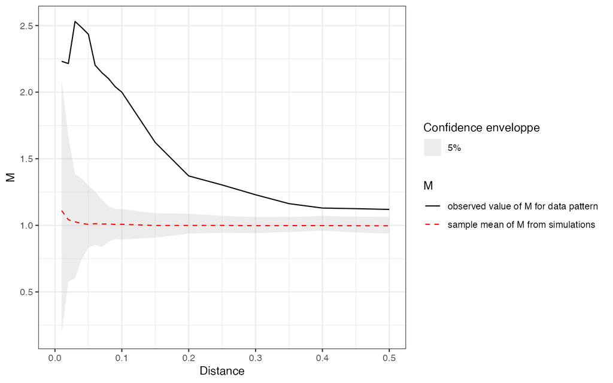

```r
if (exists("d_matrix")) {
  d_matrix %>%
    MEnvelope(r = r, ReferenceType = "Case", Global = TRUE) %>%
    autoplot()
}
```

## 1.3 Computational performance

The `X_to_M()` function calculates the $M$ function and returns the vector of its values for each distance. It is useful for measuring execution times.

```r
# Compute M
X_to_M <- function(X) {
  X %>%
    Mhat(r = r, ReferenceType = "Case") %>%
    pull("M")
}
```

### 1.3.1 Computing time

The time required for an exact calculation is evaluated for a range of numbers of points specified in `X_sizes`.

The sizes are limited to 10,000 points here to save time. To reproduce the results of the article, uncomment the full vector.

```r
X_sizes <- c(1000, 5000, 10000)
# Uncomment to test the full range of sizes
# X_sizes <- c(1000, 5000, 10000, 50000, 100000)
```

The `test_time()` function is used to measure the execution time of an evaluation of the $M$ function.

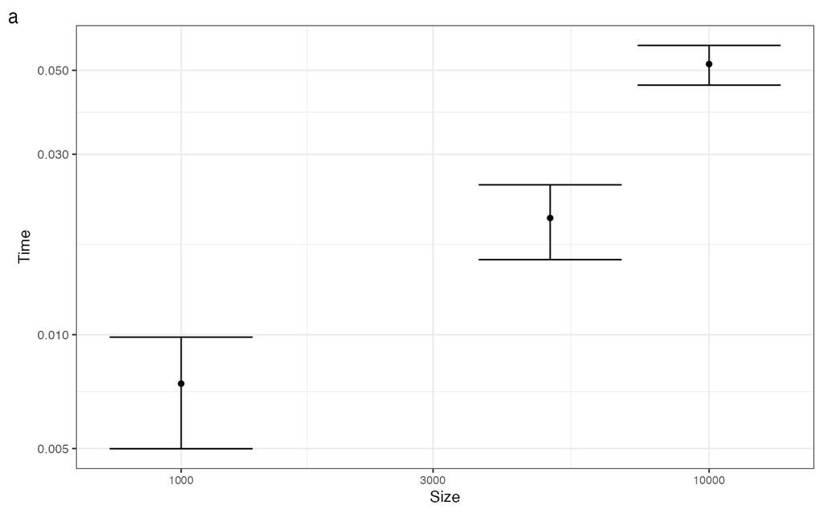

```r
library("microbenchmark")
test_time <- function(points_nb, FUN_DBM = X_to_M, times = 10L) {
  X <- X_csr(points_nb)
  microbenchmark(FUN_DBM(X), times = times) %>%
    pull("time")
}

X_sizes %>%
  sapply(FUN = test_time) %>%
  as_tibble() %>%
  pivot_longer(cols = everything()) %>%
  rename(Size = name) %>%
  group_by(Size) %>%
  summarise(Time = mean(value) / 1E9, sd = sd(value) / 1E9) %>%
  mutate(
    Size = as.double(
      plyr::mapvalues(
        .$Size,
        from = paste0("V", seq_along(X_sizes)),
        to = X_sizes
      )
    )
  ) -> M_time
M_time %>%
  ggplot(aes(x = Size, y = Time)) +
    geom_point() +
    geom_errorbar(aes(ymin = Time - sd, ymax = Time + sd)) +
    scale_x_log10() +
    scale_y_log10() +
    labs(tag = "a") +
    theme(axis.text.x = element_text(size = 8))
```

The calculation time is related to the size of the set of points by a power law.

```r
# Model
M_time %>%
  mutate(logTime = log(Time), logSize = log(Size)) ->
  M_time_log
M_time_lm <- lm(logTime ~ logSize, data = M_time_log)
summary(M_time_lm)
```

```
##
## Call:
## lm(formula = logTime ~ logSize, data = M_time_log)
##
## Residuals:
##       1       2       3
##  0.0670 -0.2226  0.1556
##
## Coefficients:
##             Estimate Std. Error t value Pr(>|t|)
## (Intercept) -10.5413     1.3843  -7.615   0.0831
## logSize       0.8065     0.1674   4.817   0.1303
##
## (Intercept) .
## logSize
## ---
## Signif. codes:
## 0 '***' 0.001 '**' 0.01 '*' 0.05 '.' 0.1 ' ' 1
##
## Residual standard error: 0.2797 on 1 degrees of freedom
## Multiple R-squared:  0.9587, Adjusted R-squared:  0.9174
## F-statistic:  23.2 on 1 and 1 DF,  p-value: 0.1303
```

The model is estimated from the average computation time of each point set size.

The *microbenchmark* package proposed by Mersmann (2023) is used to compare the computation time of the function between a set of points and a matrix of distances.

The calculation of distances is extremely fast in the `Mhat()` function: the matrix saves time, but the complete processing from a matrix is ultimately longer. Distance matrices are thus useful only in relatively small datasets (less than 4.634^{4} points by R limitations, possibly much less depending on available RAM) when distances are not euclidean.

```r
library("microbenchmark")
if (exists("d_matrix")) {
  mb <- microbenchmark(
    Mhat(X, r = r, ReferenceType = "Case", NeighborType = "Control"),
    Mhat(d_matrix, r = r, ReferenceType = "Case", NeighborType = "Control"),
    times = 10L
  )
  mb
}
```

```
## Unit: milliseconds
##                                                                     expr
##         Mhat(X, r = r, ReferenceType = "Case", NeighborType = "Control")
##  Mhat(d_matrix, r = r, ReferenceType = "Case", NeighborType = "Control")
##       min       lq     mean   median       uq
##  10.48378 10.56263 11.23496 10.74860 11.29320
##  15.75712 16.84600 19.04249 17.48449 18.19535
##       max neval
##  14.78263    10
##  30.77817    10
```

### 1.3.2 Memory

The memory used is evaluated with the *profmem* package (Bengtsson, 2021).

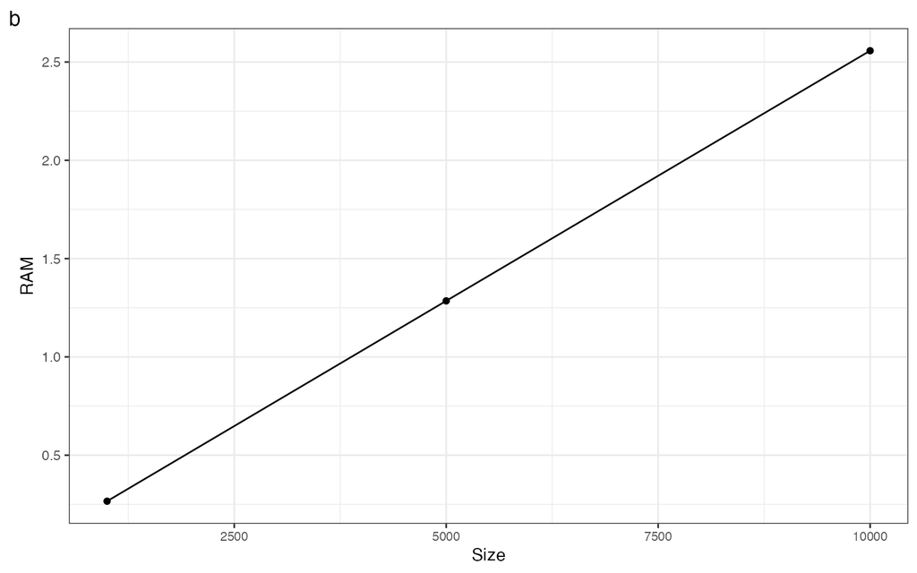

```r
# RAM
library("profmem")
test_ram <- function(points_nb, FUN_DBM = X_to_M) {
  X <- X_csr(points_nb)
  profmem(FUN_DBM(X)) %>%
    pull("bytes") %>%
    sum(na.rm = TRUE)
}
sapply(X_sizes, FUN = test_ram) %>%
  tibble(Size = X_sizes, RAM = . / 2^20) ->
  M_ram
M_ram %>%
  ggplot(aes(x = Size, y = RAM)) +
    geom_point() +
    geom_line() +
    labs(tag = "b") +
    theme(axis.text.x = element_text(size = 8))
```

The memory required (in MB) increases linearly with the number of points.

```r
# Model
lm(RAM ~ Size, data = M_ram) %>% summary()
```

```
##
## Call:
## lm(formula = RAM ~ Size, data = M_ram)
##
## Residuals:
##          1          2          3
## -0.0002283  0.0004109 -0.0001826
##
## Coefficients:
##              Estimate Std. Error t value Pr(>|t|)
## (Intercept) 1.161e-02  5.124e-04   22.65 0.028088
## Size        2.546e-04  7.907e-08 3219.98 0.000198
##
## (Intercept) *
## Size        ***
## ---
## Signif. codes:
## 0 '***' 0.001 '**' 0.01 '*' 0.05 '.' 0.1 ' ' 1
##
## Residual standard error: 0.0005042 on 1 degrees of freedom
## Multiple R-squared:      1,  Adjusted R-squared:      1
## F-statistic: 1.037e+07 on 1 and 1 DF,  p-value: 0.0001977
```

### 1.3.3 Discussion: technical limit of computing M

This code chunk predicts the computation time of large point patterns.

```r
# Time to compute 100000 points, in seconds
Mtime_1E5_s <- ceiling(M_time$Time[5])
# 1000 simulations, in minutes
Mtime_1E5_1000_min <- 1000 * Mtime_1E5_s / 60
# 5 million points, in minutes
Mtime_5E6_min <- exp(
  predict(
    M_time_lm,
    newdata = data.frame(logSize = log(5E6))
  )
) / 60
# 1000 simulations, in days
Mtime_5E6_1000_d <- 1000 * Mtime_5E6_min / 60 / 24
```

# 2 A guide to dealing with large datasets

## 2.1 First strategy: Approximating the position of points

### 2.1.1 Test setting

The number of test repetitions is set by `simulations_n`.

```r
simulations_n <- 20
```

`X_matern_list` and `X_csr_list` contain `simulations_n` drawn from the set of points. `X_matern_grouped_list` and `X_csr_grouped_list` contain the same simulations, whose points have been grouped in the grid cells.

The number of points of each point pattern is 100,000 in the article: several hours are necessary to compute the tests. In this appendix, it is set to 5000 in the parameter `par_points_comp_nb` to limit computer overhead and allow testing the code. It can be set to 100,000 to reproduce the tests of the article.

```r
# Number of points for comparison simulations
par_points_comp_nb <- 5000 # 1E5 in the article
# Simulate Matérn point patterns
X_matern_list <- replicate(
  simulations_n,
  expr = X_matern(par_points_comp_nb),
  simplify = FALSE
)
# Group points
X_matern_grouped_list <- lapply(
  X_matern_list,
  FUN = group_points,
  partitions = par_partitions
)
# Simulate CSR point patterns
X_csr_list <- replicate(
  simulations_n,
  expr = X_csr(par_points_comp_nb),
  simplify = FALSE
)
# Group points and compute M
X_csr_grouped_list <- lapply(
  X_csr_list,
  FUN = group_points,
  partitions = par_partitions
)
```

The M function is computed on each point pattern.

```r
library("pbapply")
# Compute M
M_matern_original <- pbsapply(X_matern_list, FUN = X_to_M)
M_matern_grouped <- pbsapply(X_matern_grouped_list, FUN = X_to_M)
M_csr_original <- pbsapply(X_csr_list, FUN = X_to_M)
M_csr_grouped <- pbsapply(X_csr_grouped_list, FUN = X_to_M)
```

The average values of M across simulations are plotted.

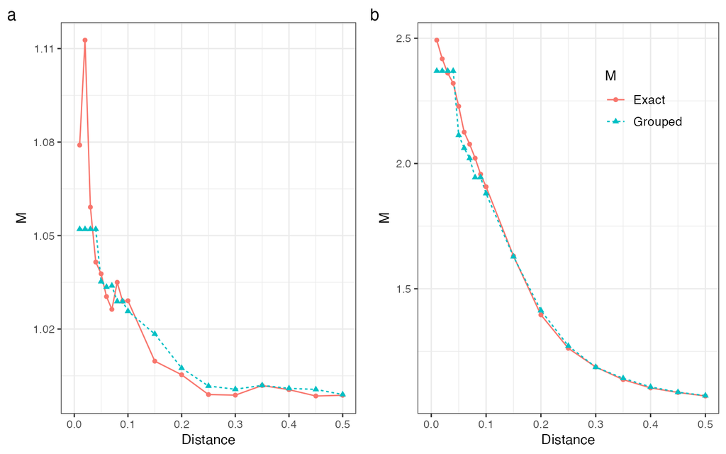

```r
library("gridExtra")
# Figure: exact and grouped M(r)
Mapproxfig <- function(M_original, M_grouped, tag) {
  tibble(
    r,
    Exact = rowMeans(M_original),
    Grouped =  rowMeans(M_grouped)
  ) %>%
    pivot_longer(
      cols = !r,
      names_to = "M",
      values_to = "value"
    ) %>%
    ggplot(aes(x = r, y = value, color = M, shape = M, linetype  = M)) +
    geom_line() +
    geom_point() +
    labs(x = "Distance", y = "M", tag = tag) +
    theme(
      legend.position = c(0.75, 0.8),
      legend.background = element_blank(),
      legend.text = element_text(size = 10)
    )
}

# Plot
grid.arrange(
  Mapproxfig(M_csr_original, M_csr_grouped, "a") +
    theme(legend.position = "none"),
  Mapproxfig(M_matern_original, M_matern_grouped, "b"),
  ncol = 2
)
```

### 2.1.2 Results

The following code compares the p-values to reject the null hypothesis of random location of points in both CSR and Matérn point patterns at each distance.

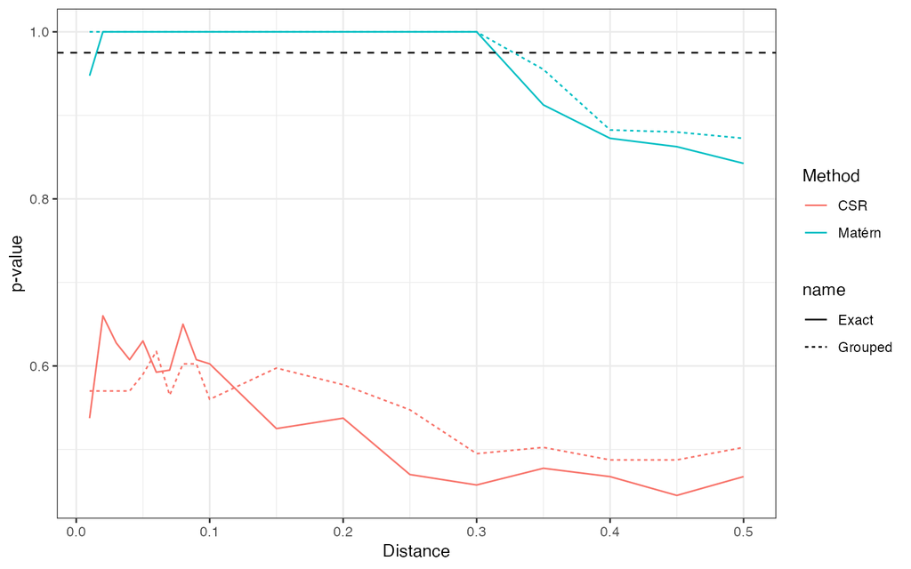

```r
# Function to calculate the departure of the grouped point pattern M p-value
# against H0 from that of the real point pattern
p_departure <- function(
    X_list,
    M_simulations = simulations_n,
    verbose = interactive()
  ) {
  # Group the points
  X_grouped_list <- lapply(
    X_list,
    FUN = group_points,
    partitions = par_partitions
  )
  # Prepare arrays to save the results
  quantiles_exact <-
    quantiles_grouped <-
    matrix(NA, nrow = length(r) - 1, ncol = simulations_n)
  for (pp_i in seq_len(simulations_n)) {
    # Iterate across the point patterns
    if (verbose) cat("Point pattern", pp_i, "of", simulations_n,"\n")
    # Calculate M with simulations
    envelope_exact <- MEnvelope(
      X_list[[pp_i]],
      r = r,
      NumberOfSimulations = M_simulations,
      ReferenceType = "Case",
      parallel = TRUE,
      verbose = FALSE,
    )
    # Individual simulations are in an attribute.
    # Extract them in a dataframe, delete the first row (distances)
    # Each column contains M(r) for a simulation
    sims_exact <- as.data.frame(attr(envelope_exact, "simfuns"))[, -1]
    # Quantiles of each M(r) in the simulations
    quantiles_exact[, pp_i] <- sapply(
      # Remove distance 0
      seq_along(r)[-1],
      FUN = function(r_i) {
        # Quantile function of the simulated M(r)
        ecdf(as.numeric(sims_exact[r_i, ]))(envelope_exact$obs[r_i])
      }
    )
    # M grouped, idem
    envelope_grouped <- MEnvelope(
      X_grouped_list[[pp_i]],
      r = r,
      NumberOfSimulations = M_simulations,
      ReferenceType = "Case",
      parallel = TRUE,
      verbose = FALSE,
    )
    sims_grouped <- as.data.frame(attr(envelope_grouped, "simfuns"))[, -1]
    quantiles_grouped[, pp_i] <- sapply(
      # Remove distance 0
      seq_along(r)[-1],
      FUN = function(r_i) {
        # Quantile function of the simulated M(r)
        ecdf(as.numeric(sims_grouped[r_i, ]))(envelope_grouped$obs[r_i])
      }
    )
  }
  return(
    tibble(
      Exact = rowMeans(quantiles_exact),
      Grouped = rowMeans(quantiles_grouped),
    )
  )
}

# Parallelize M simulations
# (https://ericmarcon.github.io/dbmss/articles/parallel.html)
library("doFuture")
plan(multisession)
departure_csr <- p_departure(X_csr_list)
departure_matern <- p_departure(X_matern_list)
plan(sequential)

# Plot the p-values
departure_csr %>%
  mutate(Pattern = "CSR", Distance = r[-1]) %>%
  bind_rows(
    departure_matern %>%
      mutate(Pattern = "Matérn", Distance = r[-1])
  ) %>%
  pivot_longer(Exact:Grouped) %>%
  ggplot() +
  geom_line(aes(x = Distance, y = value, color = Pattern, linetype = name)) +
  geom_hline(yintercept = .975, linetype = 2) +
  labs(color = "Method", y = "p-value")
```

### 2.1.3 Correlation between exact and approximated point patterns

Tidu et al. (2024) tested the effect of grouping the points by the correlation between exact and approximated *M* values. To allow comparing our results to theirs, the same approach is applied below but it is not retained in the article because all correlations shown below mainly depend on the number of points.

#### 2.1.3.1 Case of an aggregated distribution (Matérn)

The correlation between the $M$ values estimated by each method is calculated at each distance $r$.

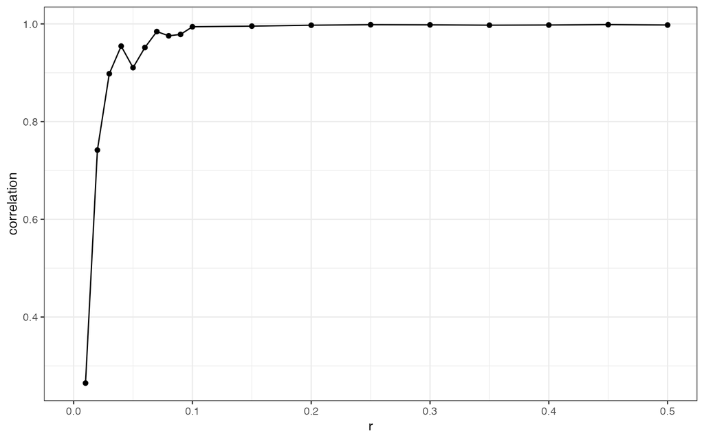

```r
# Correlation
M_cor <- function(r_value, M_original, M_grouped) {
  r_index <- which(r == r_value)
  # Return
  c(
    # Distance
    r_value,
    # Correlation
    cor(M_original[r_index, ], M_grouped[r_index, ])
  )
}
sapply(
  r,
  FUN = M_cor,
  M_original = M_matern_original,
  M_grouped = M_matern_grouped
) %>%
  t() %>%
  as_tibble() %>%
  rename(r = V1, correlation = V2) %>%
  ggplot(aes(x = r, y = correlation)) +
    geom_point() +
    geom_line()
```

The correlation is very high as soon as the distance taken into account exceeds the grid cell. The values are then compared.

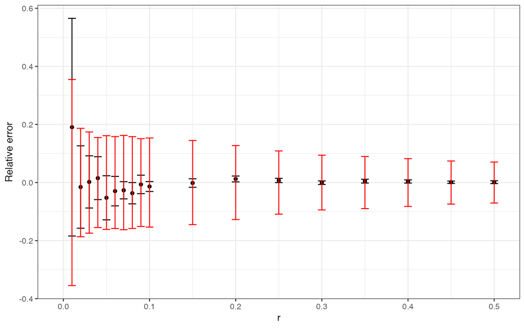

```r
# Compare values
M_bias <- function(r_value, M_original, M_grouped) {
  r_index <- which(r == r_value)
  # Return
  c(
    # Distance
    r_value,
    # Relative error
    mean((M_grouped[r_index, ] - M_original[r_index, ]) / M_original[r_index, ]),
    # Standardised error sd
    sd(M_grouped[r_index, ] - M_original[r_index, ]) / mean(M_grouped[r_index, ]),
    # Coefficient of variation
    sd(M_original[r_index, ] / mean(M_original[r_index, ]))
  )
}
sapply(
  r,
  FUN = M_bias,
  M_original = M_matern_original,
  M_grouped = M_matern_grouped
) %>%
  t() %>%
  as_tibble() %>%
  rename(r = V1, `Relative error` = V2, `Error CV` = V3, `M CV` = V4) %>%
  ggplot() +
    geom_point(aes(x = r, y = `Relative error`)) +
    geom_errorbar(
      aes(
        x = r,
        ymin = `Relative error` - `Error CV`,
        ymax = `Relative error` + `Error CV`
      )
    ) +
    geom_errorbar(aes(x = r, ymin = -`M CV`, ymax = `M CV`), col = "red")
```

The figure above shows, in red, the variability of the value of $M$ (its coefficient of variation) over the course of the simulations. By definition, the mean value is error-free. At short distances, the values of *M* vary greatly for the same point process, depending on the stochasticity of its runs. As *M* is a cumulative function, it stabilises as distance increases.

#### 2.1.3.2 Case of a completely random distribution (CSR)

The correlation between the $M$ values calculated by each method is calculated at each distance $r$.

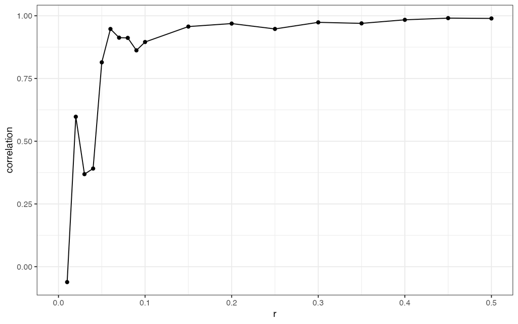

```r
# Correlation
sapply(
  r,
  FUN = M_cor,
  M_original = M_csr_original,
  M_grouped = M_csr_grouped
) %>%
  t() %>%
  as_tibble() %>%
  rename(r = V1, correlation = V2) %>%
  ggplot(aes(x = r, y = correlation)) +
    geom_point() +
    geom_line()
```

In the absence of spatial structure, correlations are much weaker.

The values are compared.

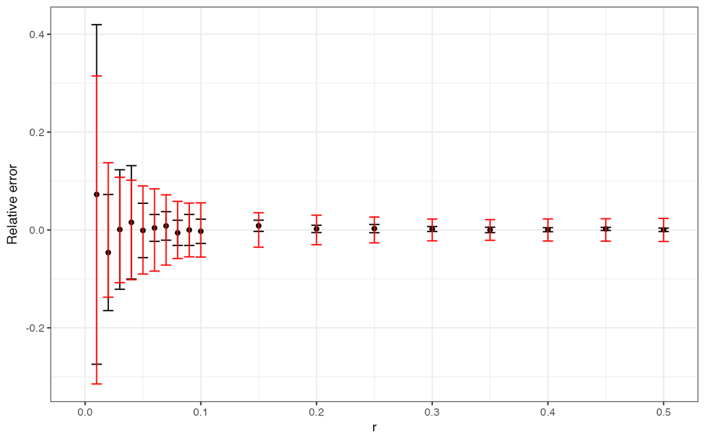

```r
# Compare values
sapply(
  r, FUN = M_bias,
  M_original = M_csr_original,
  M_grouped = M_csr_grouped
) %>%
  t() %>%
  as_tibble() %>%
  rename(r = V1, `Relative error` = V2, `Error CV` = V3, `M CV` = V4) %>%
  ggplot() +
    geom_point(aes(x = r, y = `Relative error`)) +
    geom_errorbar(
      aes(
        x = r,
        ymin = `Relative error` - `Error CV`,
        ymax = `Relative error` + `Error CV`
      )
    ) +
    geom_errorbar(aes(x = r, ymin = -`M CV`, ymax = `M CV`), col = "red")
```

The figure above is constructed in the same way as for aggregated point sets. In the absence of spatial structure, the value of *M* varies much less.

In the presence of a spatial structure, the estimation error is large at short distances. It becomes negligible beyond the grid cell.

## 2.2 Second strategy: Random thinning

The following code reproduces the figure in the article.

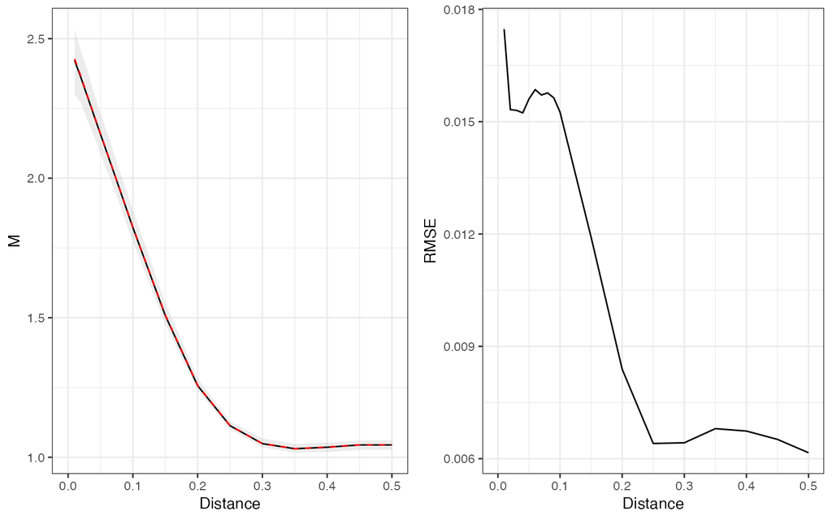

```r
# Function to compute a confidence envelope after thinning
Envelope_thinning <- function(X, r, FUN = Mhat, thinning = 1/10, nsim = 100) {
  # Repeat thinning (code from dbmss::MEnvelope)
  the_envelope <- spatstat.explore::envelope(
    X,
    fun = FUN,
    nsim = nsim,
    nrank = 1,
    r = r,
    ReferenceType = "Case",
    CheckArguments = FALSE,
    simulate = expression(rthin(X, P = thinning)),
    verbose = interactive(),
    savefuns = TRUE
  )
  attr(the_envelope, "einfo")$H0 <- "Thinned"
  # Calculate confidence intervals
  Envelope <- dbmss::FillEnvelope(the_envelope, Alpha = 0.05, Global = TRUE)
  # No edge effect correction
  attr(the_envelope, "einfo")$valname <- NULL
  # Return
  return(the_envelope)
}

# Run the test if the results have not been saved
if (file.exists("data/MThin.RData")) {
  # Do not compute if it has been saved before
  load("data/MThin.RData")
} else {
  # Draw the original point pattern: 1 million points
  pp_original_Matern <- X_matern(1E6)
  # Repeat thinning (code from dbmss::MEnvelope)
  env_M_6_5 <- Envelope_thinning(
    # Original point pattern
    pp_original_Matern,
    # Distances
    r = r,
    # Function to compute
    FUN = Mhat,
    # Thinning ratio
    thinning = 1/10,
    # Number of simulations to build the confidence envelope
    nsim = 100
  )
  # Sims contains simulated values (one line per simulation)
  Sims <- as.data.frame(attr(env_M_6_5, "simfuns"))[, -1]
  Bias <- abs(rowMeans(Sims, na.rm = TRUE) - env_M_6_5$obs)
  Variance <- apply(Sims, MARGIN = 1, FUN = var, na.rm = TRUE)
  RMSE <- sqrt(Bias^2 + Variance) / env_M_6_5$obs
  # Save the results
  save(
    env_M_6_5, RMSE,
    file = "data/MThin.RData"
  )
}
# Figure
autoplot(env_M_6_5) +
  theme(legend.position = "none") ->
  MthinFiga
tibble(RMSE, r) %>%
  ggplot(aes(x = r, y = RMSE)) +
  geom_line() +
  labs(x = "Distance") ->
  MthinFigb
grid.arrange(MthinFiga, MthinFigb, ncol = 2)
```

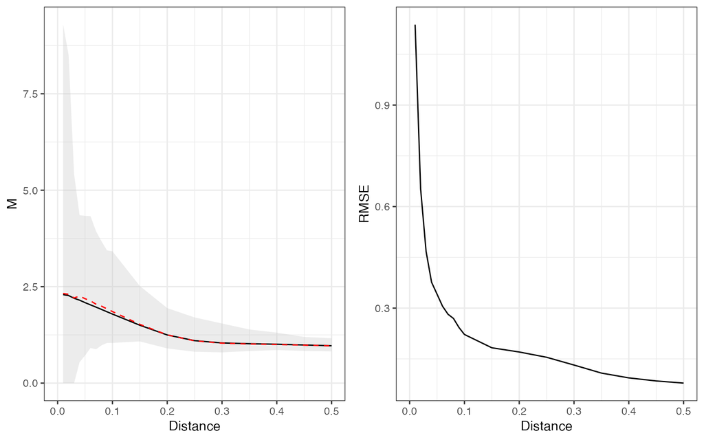

```r
# Draw the original point pattern: 100,000 points
pp_original_Matern <- X_matern(1E5)
# Repeat thinning (code from dbmss::MEnvelope)
env_M_5_3 <- Envelope_thinning(
  # Original point pattern
  pp_original_Matern,
  # Distances
  r = r,
  # Function to compute
  FUN = Mhat,
  # Thinning ratio
  thinning = 1/100,
  # Number of simulations to build the confidence envelope
  nsim = 100
)
# Sims contains simulated values (one line per simulation)
Sims <- as.data.frame(attr(env_M_5_3, "simfuns"))[, -1]
Bias <- abs(rowMeans(Sims, na.rm = TRUE) - env_M_5_3$obs)
Variance <- apply(Sims, MARGIN = 1, FUN = var, na.rm = TRUE)
RMSE <- sqrt(Bias^2 + Variance) / env_M_5_3$obs

# Figure
autoplot(env_M_5_3) +
  theme(legend.position = "none") ->
  MthinFiga
tibble(RMSE, r) %>%
  ggplot(aes(x = r, y = RMSE)) +
  geom_line() +
  labs(x = "Distance") ->
  MthinFigb
grid.arrange(MthinFiga, MthinFigb, ncol = 2)
```

# 3 Discussion and conclusion

Computing time of the *K<sub>d</sub>* , *D* and *M* functions.

Necessary functions:

```r
# Compute D
X_to_D <- function(X) {
  X %>%
    Dhat(r = r, Cases = "Case") %>%
    pull("iso")
}
# Compute Kd
X_to_Kd <- function(X) {
  X %>%
    Kdhat(r = r, ReferenceType = "Case") %>%
    pull("Kd")
}
```

Test:

```r
X_sizes %>%
  sapply(FUN = test_time, FUN_DBM = X_to_M) %>%
  as_tibble() %>%
  pivot_longer(cols = everything()) %>%
  rename(V = name, M = value) %>%
  bind_cols(
    X_sizes %>%
    sapply(FUN = test_time, FUN_DBM = X_to_D) %>%
    as_tibble() %>%
    pivot_longer(cols = everything()) %>%
    rename(V = name, D = value) %>%
    select(-V)
  ) %>%
  bind_cols(
    X_sizes %>%
    sapply(FUN = test_time, FUN_DBM = X_to_Kd) %>%
    as_tibble() %>%
    pivot_longer(cols = everything()) %>%
    rename(V = name, Kd = value) %>%
    select(-V)
  ) %>%
  pivot_longer(cols = !V)  %>%
  group_by(V, name) %>%
  summarise(Time = mean(value) / 1E9, sd = sd(value) / 1E9) %>%
  rename(Function = name) %>%
  inner_join(
    tibble(
      V = paste0("V", seq_along(X_sizes)),
      Size = X_sizes
    )
  ) -> dbm_time
```

Figure:

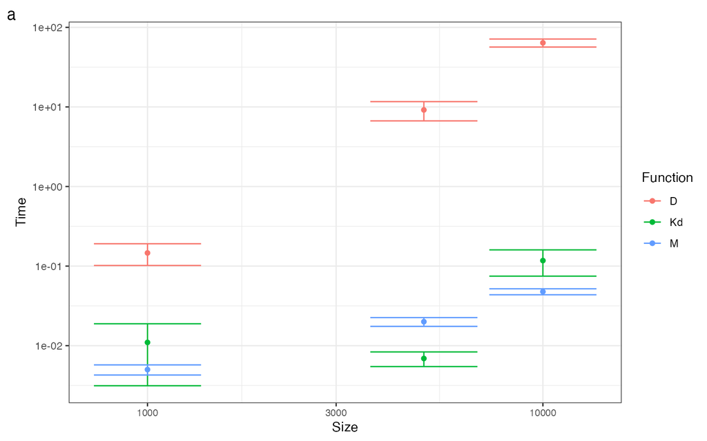

```r
dbm_time %>%
  ggplot(aes(x = Size, y = Time, color = Function)) +
    geom_point() +
    geom_errorbar(aes(ymin = Time - sd, ymax = Time + sd)) +
    scale_x_log10() +
    scale_y_log10() +
    labs(tag = "a") +
    theme(axis.text.x = element_text(size = 8))
```

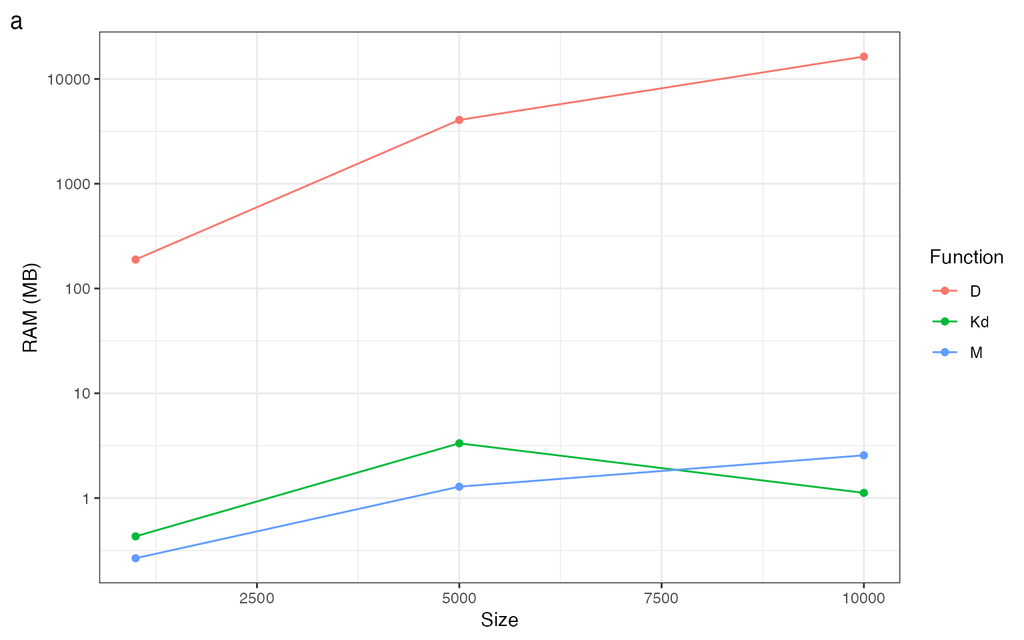

```r
# RAM
X_sizes %>%
  as_tibble() %>%
  rename(Size = value) %>%
  bind_cols(
    X_sizes %>%
    sapply(FUN = test_ram, FUN_DBM = X_to_M) %>%
    as_tibble() %>%
    rename(M = value)
  ) %>%
  bind_cols(
    X_sizes %>%
    sapply(FUN = test_ram, FUN_DBM = X_to_D) %>%
    as_tibble() %>%
    rename(D = value)
  ) %>%
  bind_cols(
    X_sizes %>%
    sapply(FUN = test_ram, FUN_DBM = X_to_Kd) %>%
    as_tibble() %>%
    rename(Kd = value)
  ) %>%
  pivot_longer(cols = !Size) %>%
  # Convert RAM to MB
  mutate(value = value / 2^20) ->
  M_ram

M_ram %>%
  ggplot(aes(x = Size, y = value, color = name)) +
    geom_point() +
    geom_line() +
    scale_y_log10() +
    labs(tag = "a") +
    labs(y = "RAM (MB)", color = "Function")
```

# References

Bengtsson, H. (2021). A Unifying Framework for Parallel and Distributed Processing in R Using Futures. *The R Journal*, *13*(2), 208.

Duranton, G., & Overman, H. G. (2005). Testing for Localisation Using Micro-Geographic Data. *Review of Economic Studies*, *72*(4), 1077–1106.

Marcon, E., & Puech, F. (2017). A Typology of Distance-Based Measures of Spatial Concentration. *Regional Science and Urban Economics*, *62*, 56–67.

Marcon, E., Traissac, S., Puech, F., & Lang, G. (2015). Tools to characterize point patterns: dbmss for R. *Journal of Statistical Software*, *67*(3), 1–15.

Matérn, B. (1960). Spatial Variation. *Meddelanden Från Statens Skogsforskningsinstitut*, *49*(5), 1–144.

Mersmann, O. (2023). *Microbenchmark: Accurate Timing Functions* [Manual].

Scholl, T., & Brenner, T. (2015). Optimizing Distance-Based Methods for Large Data Sets. *Journal of Geographical Systems*, *17*(4), 333–351. https://doi.org/10.1007/s10109-015-0219-1

Tidu, A., Guy, F., & Usai, S. (2024). Measuring Spatial Dispersion: An Experimental Test on the *M*-Index. *Geographical Analysis*, *56*(2), 384–403. https://doi.org/10.1111/gean.12381